# Laos: Preliminary Allometric Analyses

Jessica Orozco

## **Above and Belowground Biomass Distribution**

The following two graphs represent the average amount of plant (fresh & dry) tissue that lies aboveground and belowground in Phetlamka and Xekatam; either the total biomass ( **Fig. 1**) or the proportion of total tissue ( **Fig. 2** ). The tissues in the aboveground portion include leaf, cherry , branch and stem biomass while the belowground includes the stump, structural and fine root biomass. It appears that trees in both locations produce and distribute their above and below biomass similiarly (statistical anaylysis in process). The low amount of belowground may indicate that aboveground tissue plays an important role in energy storage.

### Total biomass(g)

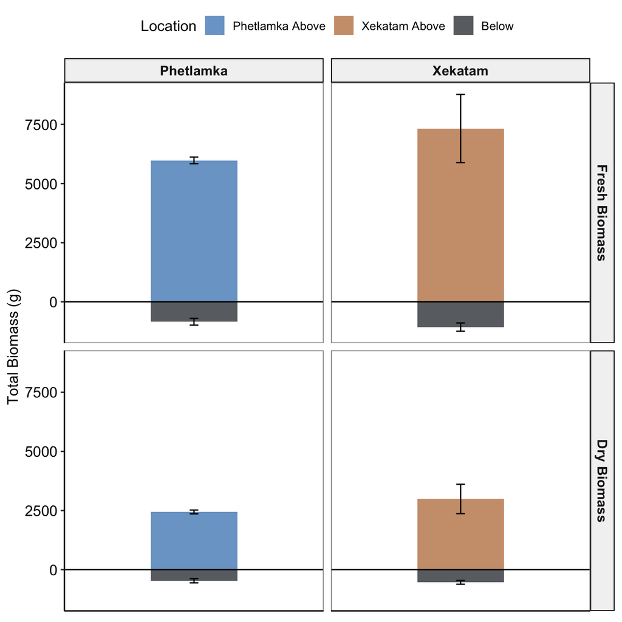

**Fig. 1** Total Fresh and Dry Above and Belowground Biomass (g) Distribution within trees in Phetlamka and Xekatam (±se)

### Fractional biomass

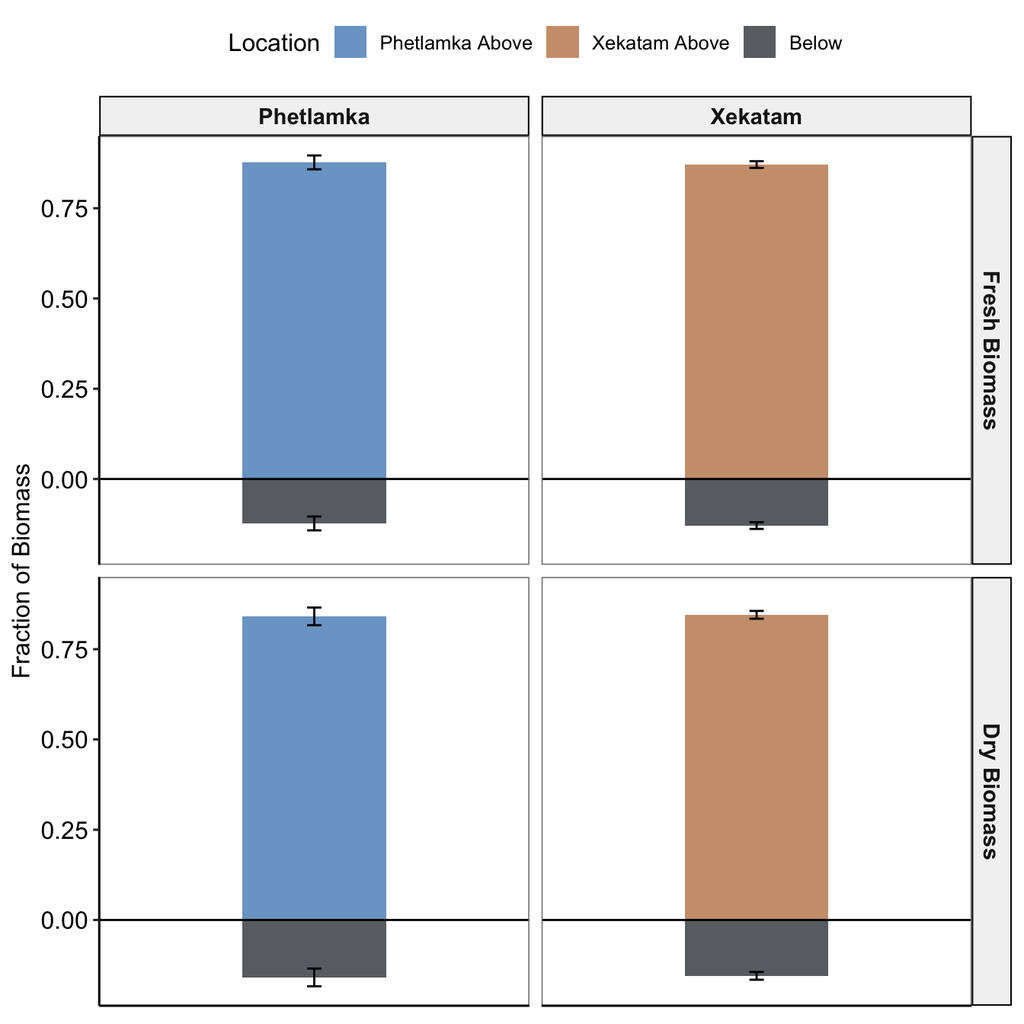

**Fig. 2** Fractional Fresh and Dry Above and Belowground Biomass Distribution within trees in Phetlamka and Xekatam (±se)

## **Vertical Distribution of Biomass**

**Fig. 3** and **Fig. 4** picture the distribution of total biomass (fresh & dry) and fractional biomass (fresh & dry) along the vertical axis. Each section accounts for 10% of the total height, where 10 is at the top of the tree while 100 is at the base. Despite the similarities between their aboveground and belowground biomass distribution ( **Fig. 1** & **Fig. 2**), the vertical allocation differs along the axis between the two locations. Coffee plants in Phetlamka increase their biomass down the axis giving a ‘pyramid-like’ appearance while in Xekatam plants seem to maintain a more homogeneous ‘box-like’ distribution of biomass, these trends are most notable in the leaf and wood. Interestingly, when we look at the total amounts of leaves and wood ( **Fig. 5** ) there isn’t much of a difference between the two sites (statistical analysis in process).

### Total biomass(g)

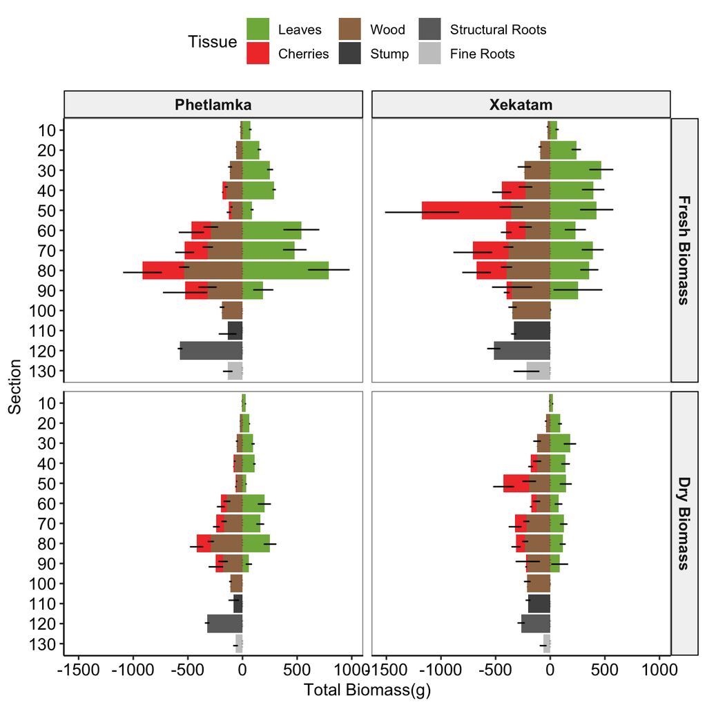

**Fig. 3** Total Fresh and Dry Biomass (g) Distribution within trees across sections in Phetlamka and Xekatam (±se)

### Fractional biomass

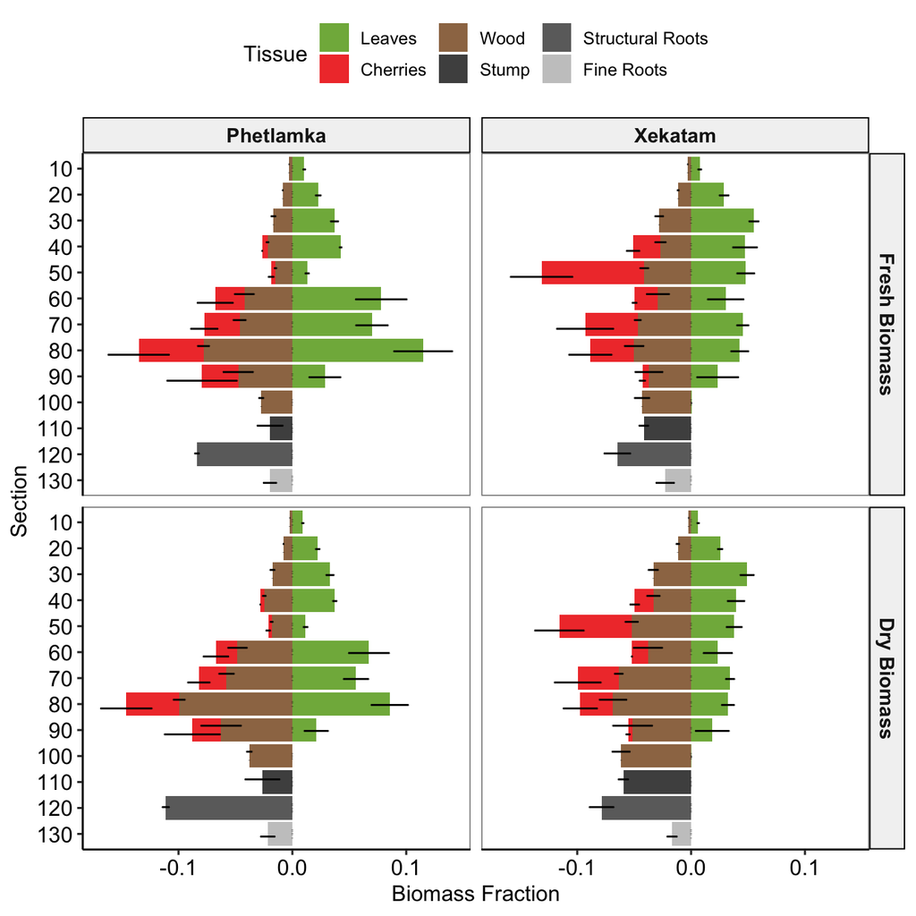

**Fig. 4** Fractional Fresh and Dry Biomass Distribution within trees across sections in Phetlamka and Xekatam (±se)

### Total aboveground distribution between tissues

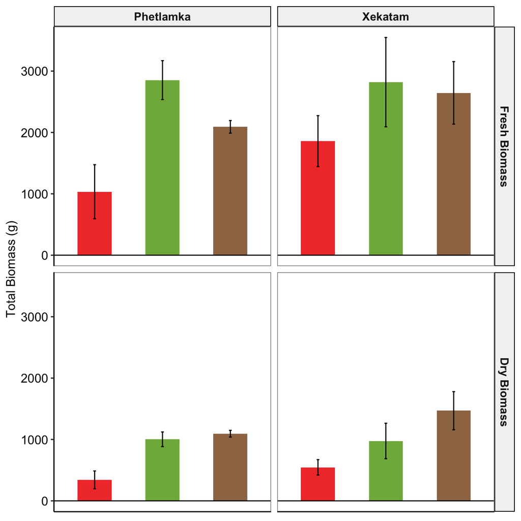

**Fig. 5** Total Aboveground Fresh and Dry Biomass (g) between tissues within trees in Phetlamka and Xekatam (±se)

## **Branch-level Analyses**

The structure of the following five graphs is the same; the center displays the relationship between the two variables while the margins represent the density plots of each variable.

The average load of cherries per branch is similar at both locations ( **Fig. 6 -9** ), with the majority of branches producing small amounts of cherries. However, when we look at the branches with the heaviest loads, we see that plants in Xekatam have more branches with heavy loads ( **Fig. 7**). In general, there seems to be a weak correlation between cherry load and leaf area, branch length and branch diameter ( **Fig. 6, 8 & 9**). Moreover, there is a strong relationship between branch cross-sectional area and leaf area ( **Fig. 10**), representative of water supply and evaporative demand.

### Relationship between cherry and leaf dry mass

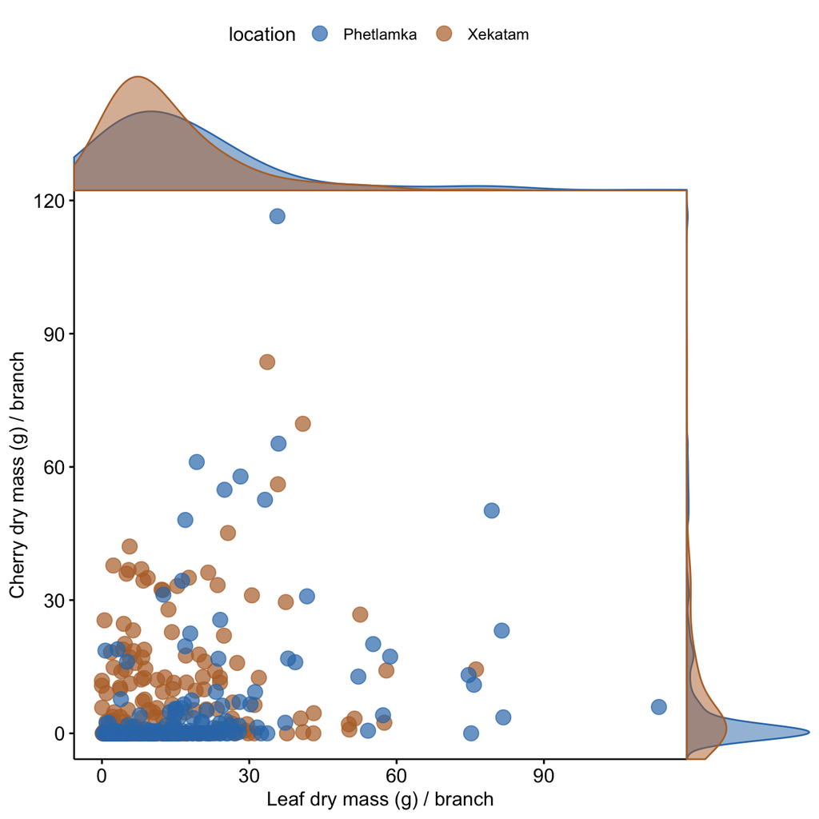

**Fig. 6** Cherry dry mass (g) production by leaf dry mass (g). Top margin displays the leaf dry mass density plot, while the right margin plot the cherry dry mass density plot.

### Relationship between cherry and leaf dry mass in the highest producing branches (> 15 g)

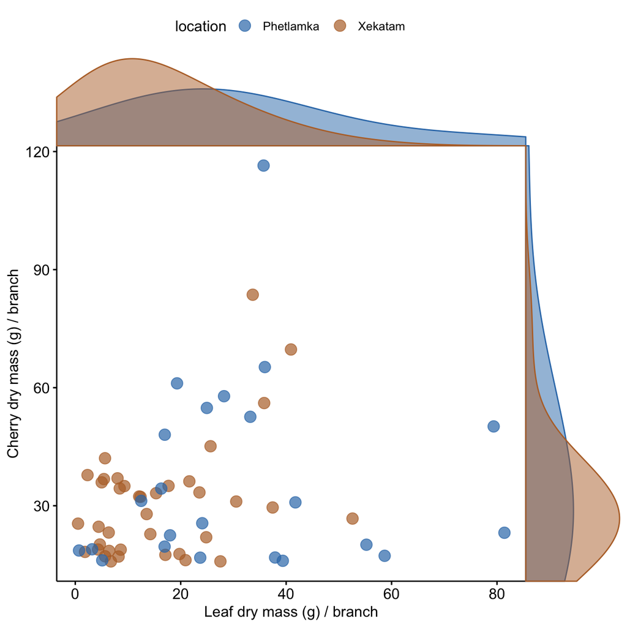

**Fig. 7** Cherry dry mass (g) by leaf dry mass (g) in branches highest-producting branches (>15g). Top margin displays the leaf dry mass density plot, while the right margin plot the cherry dry mass density plot.

### Relationship between cherry dry mass and branch length

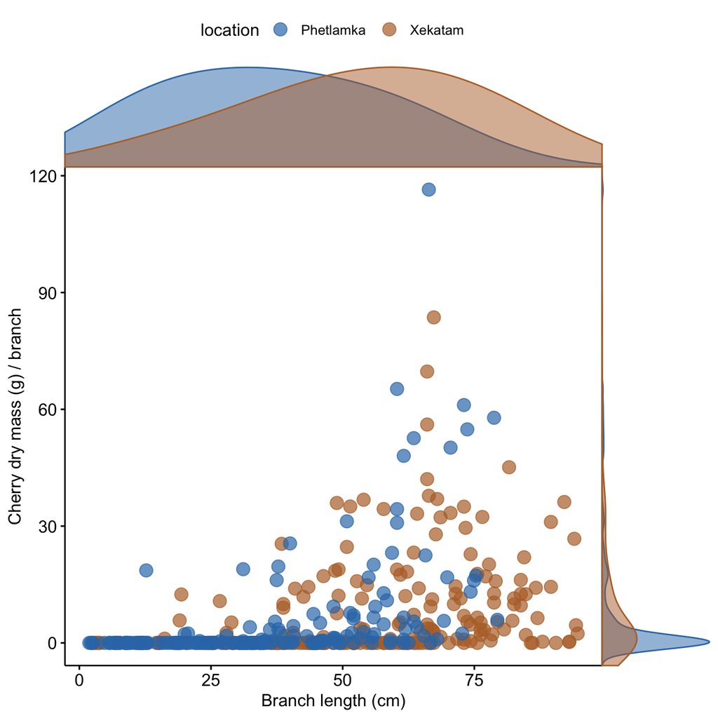

**Fig. 8** Cherry dry mass (g) by branch length (cm).Top margin displays the branch length density plot, while the right margin plot the cherry dry mass density plot.

### Relationship between cherry dry mass and branch diameter

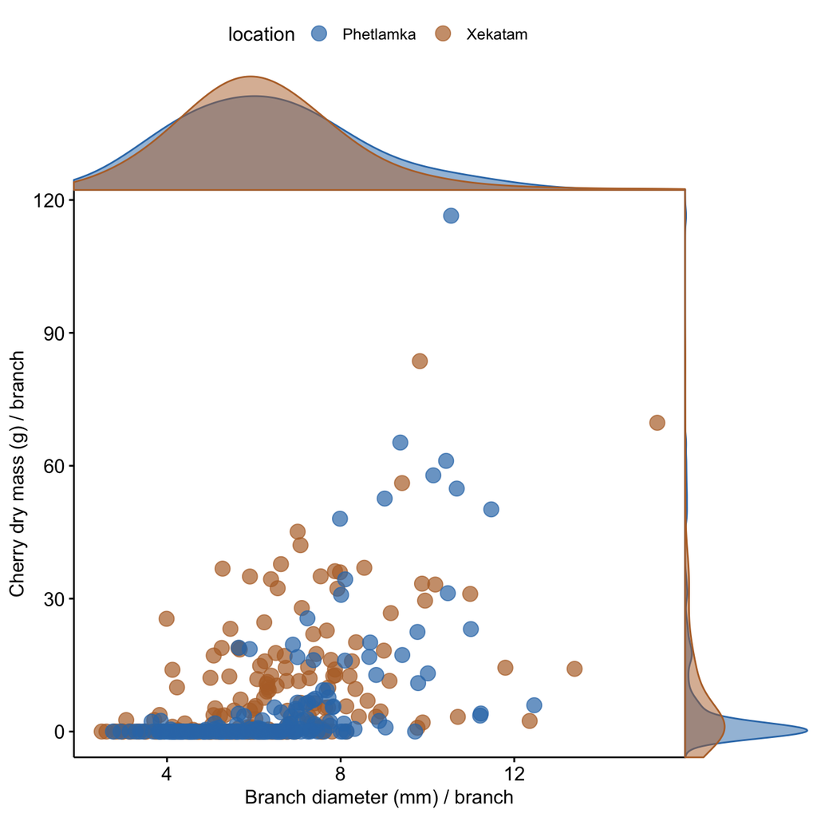

**Fig. 9** Cherry dry mass (g) by branch diameter (mm). Top margin displays the branch diameter density plot, while the right margin plot the cherry dry mass density plot.

### Relationship between leaf and branch cross-sectional areas

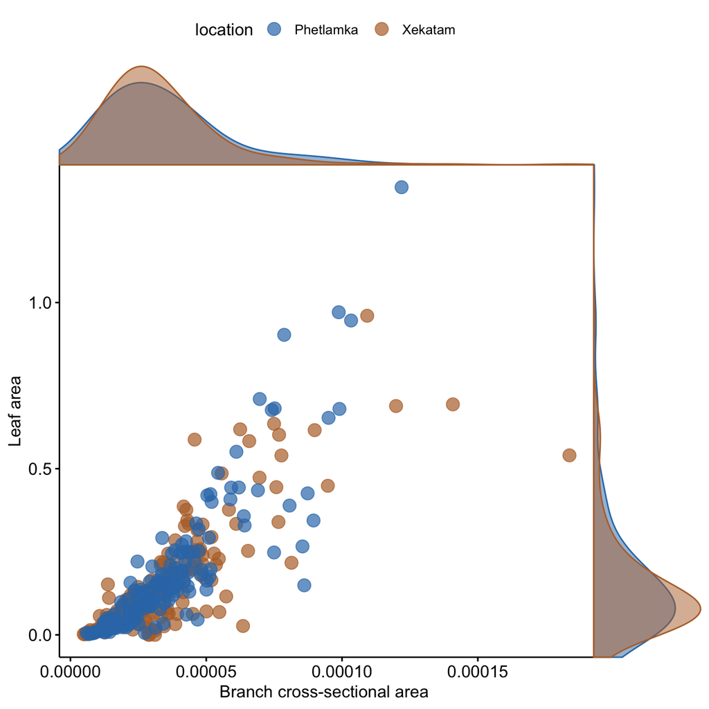